# Lab 3

STAT 359 Data Visualization

# Overview

You should have already read chapters 1 and 2 in Hadley Wickham’s *ggplot2: Elegant Graphics for Data Analysis* and completed lab 2. The goal of this lab is to continue deepening your understanding of `ggplot2` as a data visualization tool and now to begin using this tool to solve more abstract problems.

# Dataset

We will be utilizing data from Kaggle (https://www.kaggle.com/) which contains historical prices and sales of avocados in the United States.

- `[first column]` - Row identifier
- `Date` - The date of the observation
- `AveragePrice` - The average price of a single avocado
- `Total Volume` - Total number of avocados sold
- `4046` - Total number of avocados with PLU 4046 sold
- `4225` - Total number of avocados with PLU 4225 sold
- `4770` - Total number of avocados with PLU 4770 sold
- `Total Bags` - The total number of bags sold
- `Small Bags` - The total number of small bags sold
- `Large Bags` - The total number of large bags sold
- `XLarge Bags` - The total number of extra large bags sold
- `type` - Conventional or organic
- `year` - The year
- `region` - The city or region of the observation

# Tasks

Your goal is to answer the below questions by making data visualizations using ggplot. There are different ways to answer each question, however some visualization choices are better suited than others. It is up to you whether to use the optional parameters available for each geom. Challenges are optional for undergraduates, but required for graduate students.

Challenge: for each question below, create the plot request AND a second version which distinguishes between *conventional* and *organic* avocados (hint: use either the optional parameters provided by the geoms OR use facets).

```r
# Import libraries
library(tidyverse)
library(ggthemes)
library(lubridate)

# ggplot has various themes. Google them. The minimal theme is a safe bet.
theme_set(theme_minimal())

# Import the data
avocado_data <- read_csv('avocado.csv')

# Filter the data to only contain aggregate values
avocado_data <- avocado_data %>%
  filter(region == 'TotalUS')

# Add new variables and convert other variables to be factors
avocado_data <- avocado_data %>%
  mutate(month = month(Date),
         volumePerBag = `Total Volume` / `Total Bags`,
         region = factor(region),
         type = factor(type),
         year = factor(year))

# View the data (You should ALWAYS do this!)
head(avocado_data)
```

```
## # A tibble: 6 x 16
##      X1 Date       AveragePrice `Total Volume` `4046` `4225` `4770`
##   <int> <date>            <dbl>          <dbl>  <dbl>  <dbl>  <dbl>
## 1     0 2015-12-27         0.95      27297984. 9.63e6 1.02e7 1.18e6
## 2     1 2015-12-20         0.98      25083647. 8.71e6 9.33e6 1.20e6
## 3     2 2015-12-13         0.93      28041335. 9.86e6 1.08e7 1.02e6
## 4     3 2015-12-06         0.89      28800397. 9.41e6 1.22e7 9.32e5
## 5     4 2015-11-29         0.99      22617999. 8.09e6 9.00e6 7.31e5
## 6     5 2015-11-22         0.96      25114228. 8.57e6 1.04e7 8.05e5
## # ... with 9 more variables: `Total Bags` <dbl>, `Small Bags` <dbl>,
## #   `Large Bags` <dbl>, `XLarge Bags` <dbl>, type <fct>, year <fct>,
## #   region <fct>, month <dbl>, volumePerBag <dbl>
```

### Examining your data

0. How many columns and rows does my dataset contain? (hint: use the dim() function)

```r
dim(avocado_data)
```

```
## [1] 338  16
```

1. Which year has the most observations (i.e. number of rows in the data)?

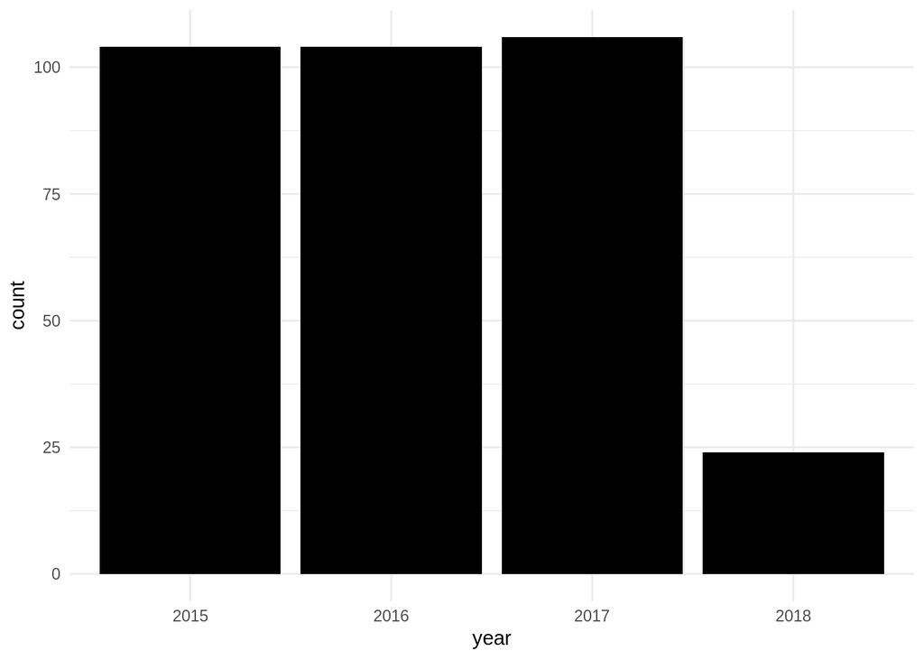

```r
# Without Challenge
ggplot(avocado_data, aes(year)) +
  geom_bar(fill = 'black')
```

### Descriptive Analysis

2. What is the distribution of total avocado sales volume?

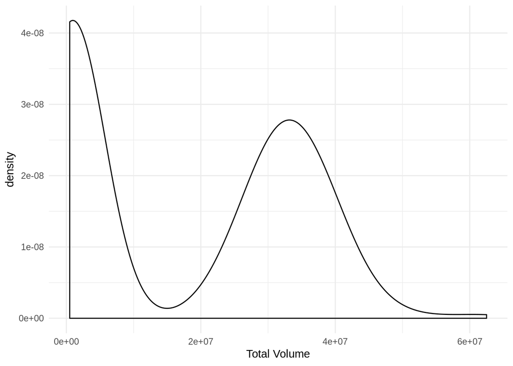

```r
# Without Challenge
ggplot(avocado_data, aes(`Total Volume`)) +
  geom_density()
```

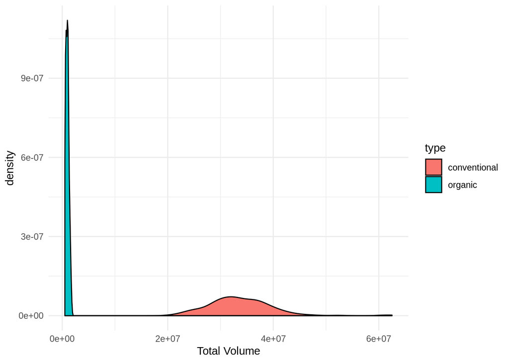

```r
# With Challenge
ggplot(avocado_data, aes(`Total Volume`)) +
  geom_density(aes(fill = type))
```

3. What is the 25th, 50th (median), and 75th percentile price points for avocados each year?

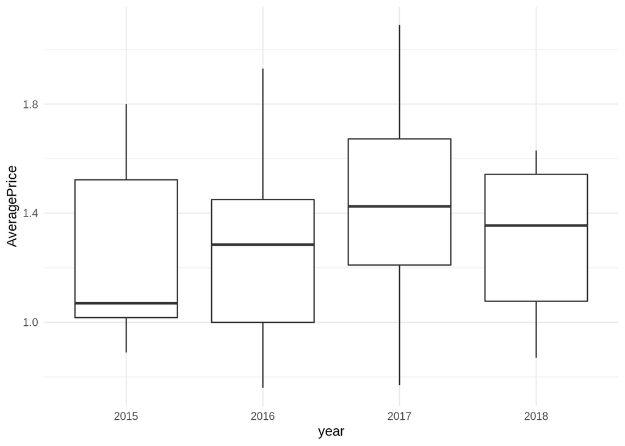

```r
# Without Challenge
ggplot(avocado_data, aes(year, AveragePrice)) +
  geom_boxplot()
```

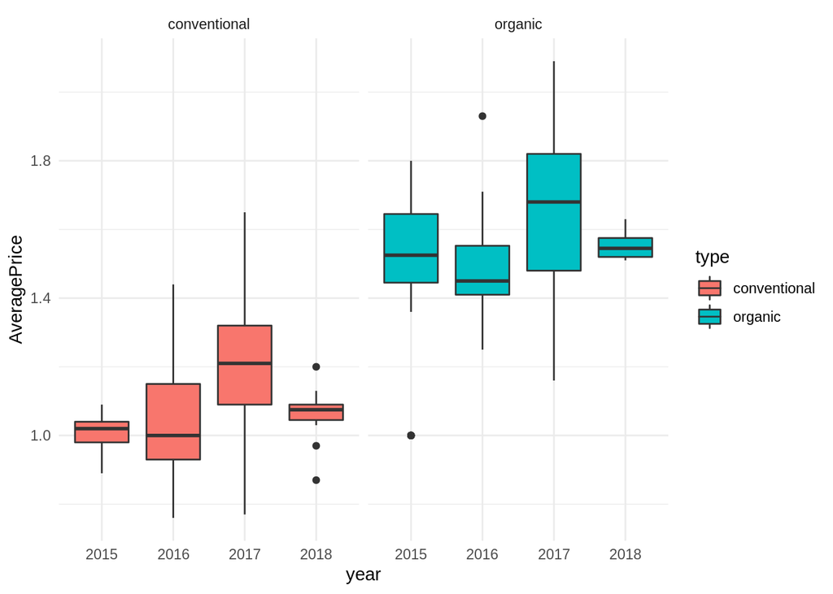

```r
# With Challenge
ggplot(avocado_data, aes(year, AveragePrice)) +
  geom_boxplot(aes(fill = type)) +
  facet_wrap(~ type)
```

```r
# Create a subset of my data
organic_data <- filter(avocado_data, type == 'organic')
```

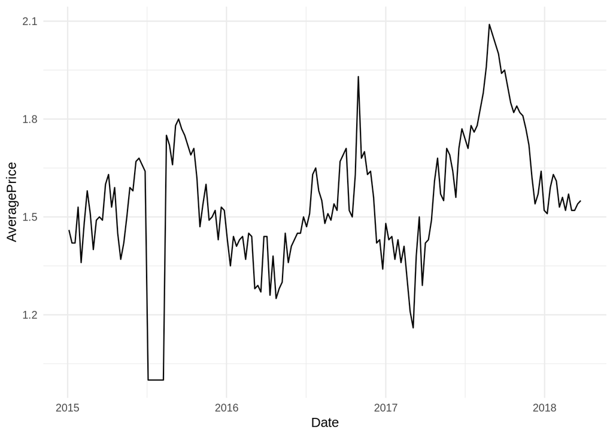

```r
# Without Challenge
ggplot(organic_data, aes(Date, AveragePrice)) +
  geom_line()
```

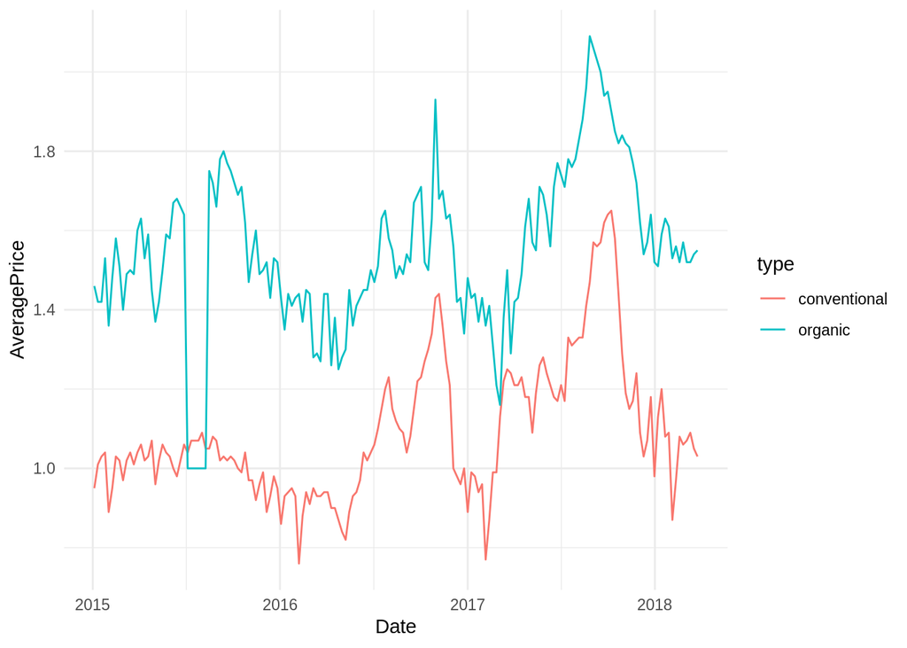

```r
# With Challenge
ggplot(avocado_data, aes(Date, AveragePrice)) +
  geom_line(aes(color = type))
```

5. Does volume per bag have a trend over time (i.e. year)?

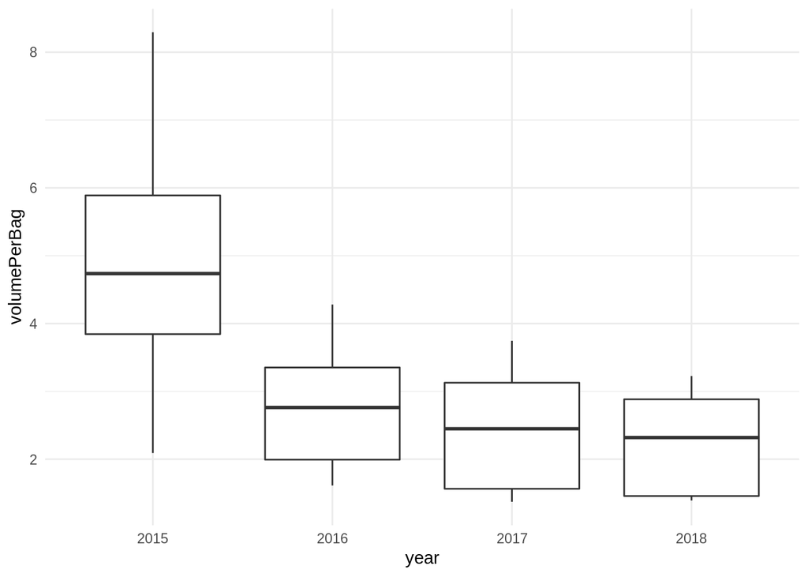

```r
# Without Challenge
ggplot(avocado_data, aes(year, volumePerBag)) +
  geom_boxplot()
```

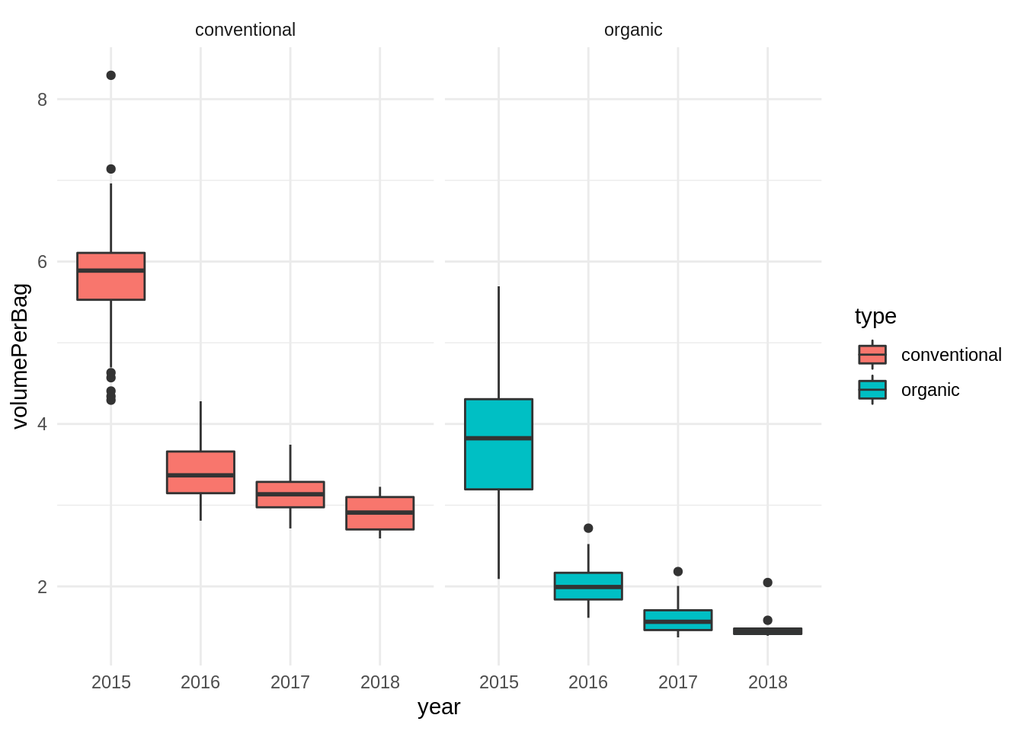

```r
# With Challenge
ggplot(avocado_data, aes(year, volumePerBag)) +
  geom_boxplot(aes(fill = type)) +
  facet_wrap(~ type)
```

6. Is there an association between total volume and month?

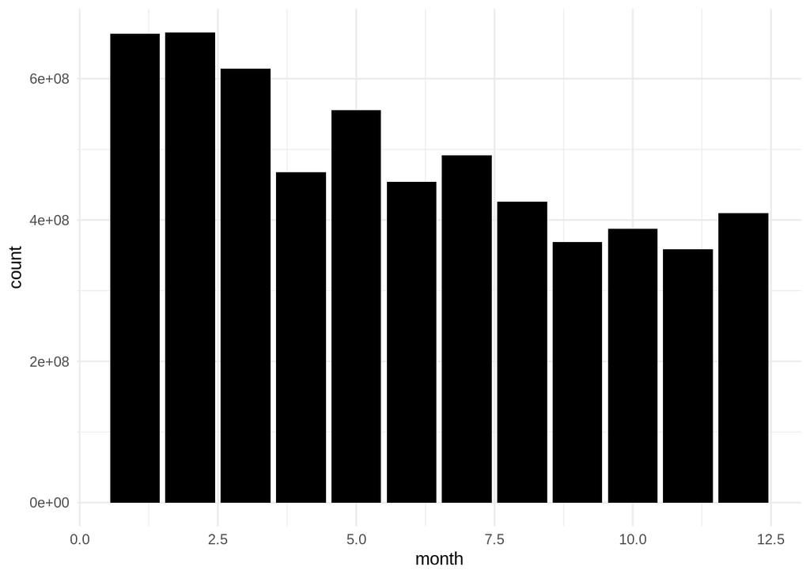

```r
# Without Challenge
ggplot(avocado_data, aes(month)) +
  geom_bar(aes(weight = `Total Volume`), fill = 'black')
```

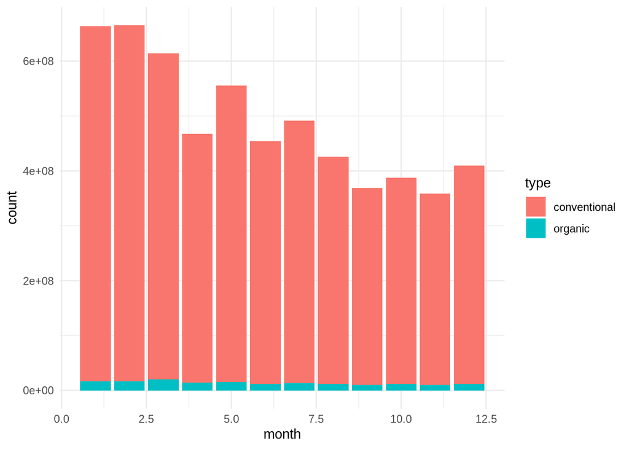

```r
# With Challenge
ggplot(avocado_data, aes(month)) +
  geom_bar(aes(weight = `Total Volume`, fill = type))
```

7. Is there an association between average price and volume? (hint: you may need to use 2 geoms to construct this plot)

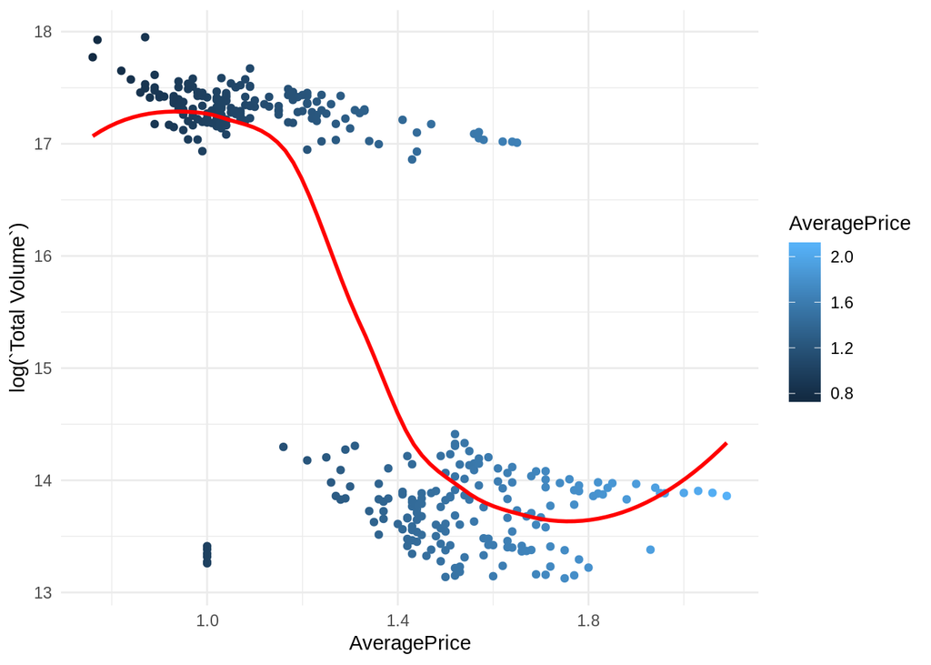

```r
# Without Challenge
ggplot(avocado_data, aes(AveragePrice, log(`Total Volume`), color = AveragePrice)) +
  geom_point() +
  geom_smooth(color = 'red', se = FALSE)
```

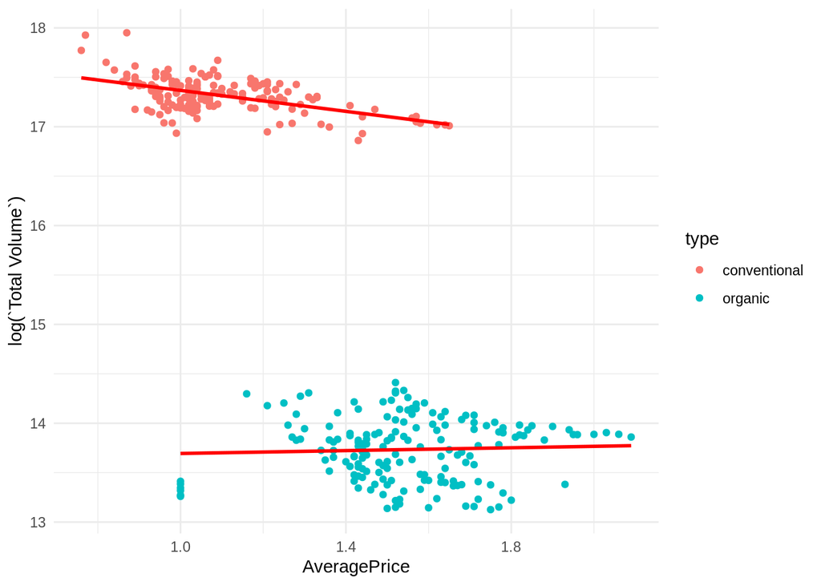

```r
# With Challenge
ggplot(avocado_data, aes(AveragePrice, log(`Total Volume`), color = type, group = type)) +
  geom_point() +
  geom_smooth(color = 'red', se = FALSE, method = lm)
```

8. Given the above graphs, answer the below questions:
1. What year has the least data?
2. What year has sold avocados at the highest average price?
3. Where there any large increases and/or decreases in the price of avocados the past few years?
4. Is there a trend in the volume of avocados per bag? If so, what is it?
5. What other visualizations do you think you should explore?